# cm005 Worksheet: Exploring Geometric Objects

Allie Choate

1/29/2020

## Preliminary

**Data:**

```r
gapminder<- gapminder
```

## Exercise 1: Bar Chart Grammar (Together)

Consider the following plot. Don’t concern yourself with the code at this point.

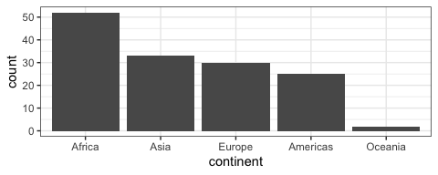

```r
gapminder %>%
  filter(year == 2007) %>%
  mutate(continent = fct_infreq(continent)) %>%
  ggplot(aes(continent)) +
  geom_bar() +
  theme_bw()
```

Fill in the seven grammar components for this plot.

[output not shown]

## Exercise 2: `ggplot2` Syntax (Your Turn)

The following is a tsibble (a special type of tibble containing time series data, which we’ll see more of later), stored in the variable `mauna`, of CO$_2$ concentrations collected monthly at the Mauna Loa station.

Execute this code to store the data in `mauna`:

```r
(mauna <- tsibble::as_tsibble(co2) %>%
   rename(month = index, conc = value))
```

```
## # A tsibble: 468 x 2 [1M]
##       month  conc
##       <mth> <dbl>
##  1 1959 Jan  315.
##  2 1959 Feb  316.
##  3 1959 Mar  316.
##  4 1959 Apr  318.
##  5 1959 May  318.
##  6 1959 Jun  318
##  7 1959 Jul  316.
##  8 1959 Aug  315.
##  9 1959 Sep  314.
## 10 1959 Oct  313.
## # … with 458 more rows
```

### 2(a)

Produce a line chart showing the concentration over time. Specifically, the plot should have the following grammar components:

| Grammar Component | Specification |
| --- | --- |
| **data** | `mauna` |
| **aesthetic mapping** | x: month, y: conc |
| **geometric object** | lines |
| scale | linear |
| statistical transform | none |
| coordinate system | rectangular |
| facetting | none |

Fill in the blanks to obtain the plot:

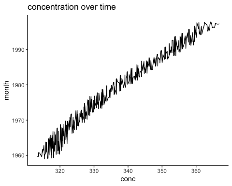

```r
p<- ggplot(mauna, aes(x=conc, y=month)) +
  scale_x_continuous() +
  geom_line() +
  theme_classic() + labs(title="concentration over time")

p
```

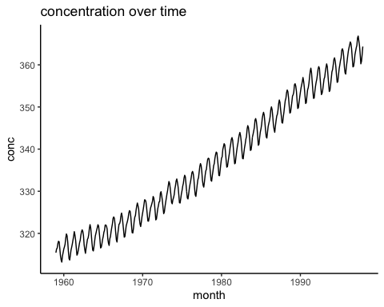

```r
### apparently month should be on the x-axis?
p1<- ggplot(mauna, aes(x=month, y=conc)) +
  geom_line() +
  theme_classic() +
  labs(title="concentration over time")
p1
```

### 2(b)

It turns out that you’re allowed to specify the aesthetic mappings in a `geom` layer instead of, or in addition to, in the `ggplot()` function, with the following rules:

- Aesthetics appearing in a `geom` layer apply only to that layer.
- If there are conflicting aesthetics in both the `ggplot()` function and the `geom` layer, the `geom` layer takes precedence.

The following code mistakenly puts the month variable on the y-axis. Fill in the `FILL_THIS_IN` so that you still obtain the same result as above.

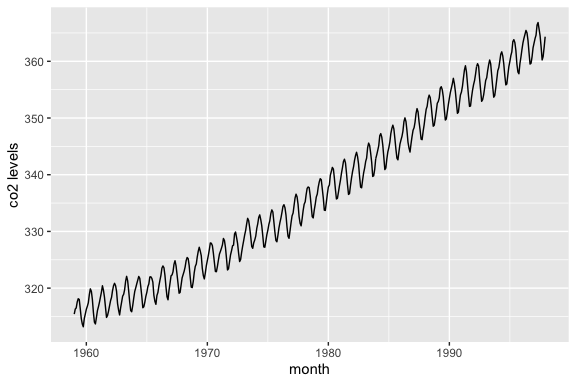

```r
ggplot(mauna, aes(y = month)) +
  geom_line(aes(x = month, y=conc)) + ylab("co2 levels")
```

### 2(c)

You can store the output of the plot in a variable, too. Store the plot from 2(a) in the variable named `p`, then add a layer to `p` that adds green points to the plot.

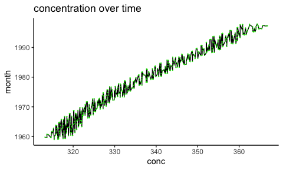

```r
p + geom_point(colour = "green", size=.1, alpha=.6)
```

### 2(d)

What’s wrong with the following code? Fix it.

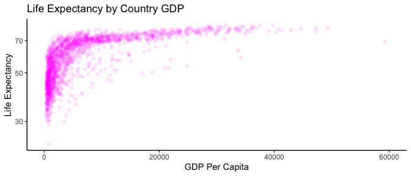

```r
ggplot(gapminder, aes(x= gdpPercap, y=lifeExp)) +
  geom_point(col = "magenta",alpha = 0.1) +
  theme_classic() +
  scale_y_log10() + #optional
  xlim(0,60000)+
  labs(x="GDP Per Capita", y="Life Expectancy", title="Life Expectancy by Country GDP")
```

### 2(e) BONUS

So you’re a ggplot2 pro? Then, let’s see this plot adapted to polar coordinates.

Specifically:

- angle is month (January through December)
- radius is CO$_2$ concentration

The plot should look like a spiral, or concentric circles.

**Polar Coordinate Plot:**

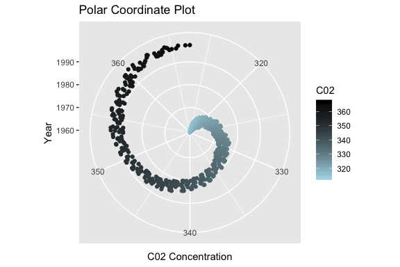

```r
ggplot(mauna, aes(x=conc, y=month)) +
  geom_point(aes(colour = conc)) +
   scale_colour_gradient(low = "lightblue", high = "black")+
  coord_polar(theta="x") +
  labs(x= "C02 Concentration", y="Year", title="Polar Coordinate Plot", colour="C02")
```

**Messing around with other pretty variations:**

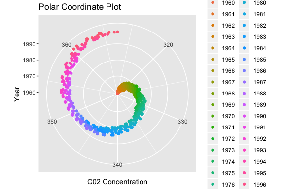

```r
mauna$newyear<- format(as.Date(mauna$month, format="%d/%m/%Y"),"%Y")
ggplot(mauna, aes(x=conc, y=month, color=newyear)) +
    geom_point()+
coord_polar(theta="x") +
  labs(x= "C02 Concentration", y="Year", title="Polar Coordinate Plot", fill="Year")
```

Using just the means of C02 across time - this probs isn’t right lol.

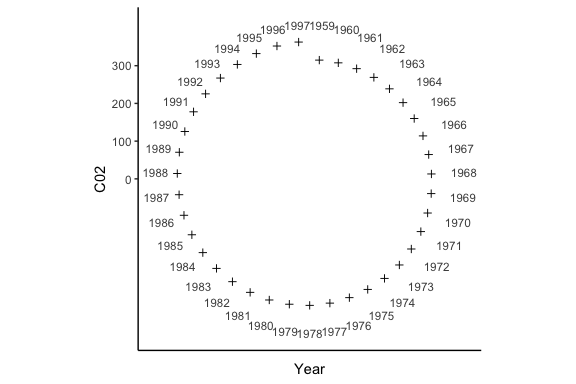

```r
#mauna$newyear<- as.numeric(mauna$newyear)

conc.mean<-round(tapply(mauna$conc, mauna$newyear, mean),4)
dat<- cbind.data.frame(paste0("19", 59:97), conc.mean)
names(dat)<- c("Year", "C02")
radius<- dat$Year
angle<- dat$C02

# plot
ggplot(dat, aes(x=Year, y=C02)) +
  geom_point(shape=3) +
  geom_spoke(aes(angle = angle, radius = radius)) +
  theme_classic() +
  coord_polar() +
  expand_limits(y = 0)
```

**I made a bug**

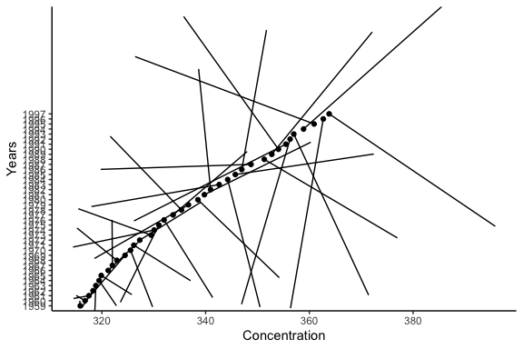

```r
ggplot(dat, aes(x=C02, y=Year)) +
  geom_point() +
  geom_spoke(aes(angle = angle, radius = as.numeric(radius))) +
  labs(x="Concentration", y="Years") +
  theme_classic()
```